# Descriptive Statistics

Lex Hembree

2025-09-27

## Descriptive Statistics on *sales_data_sample* for each numeric attribute in the dataset

```r
library(ggplot2)
library(dplyr)
library(lubridate)
library(scales)
library(moments)
```

##### Since this is a large markdown, I figured I should place some final thoughts at the beginning. While each data point can provide various information for analysis, we should strive or at least attempt multiple views/data points to gain a whole concept view of the data because there may be items that skew what we get as a result. Multiple quantity sizes and unit prices can casue large variances within the data.

##### As analysts we can further breakdown data sets into specialized views (by product or region, possibly both) and begin to tell a story with increased fidelity.

### Distribution

##### Types of Distributions: Going to try multiple (3) distribution visuals to see which is best

##### Bell Curve

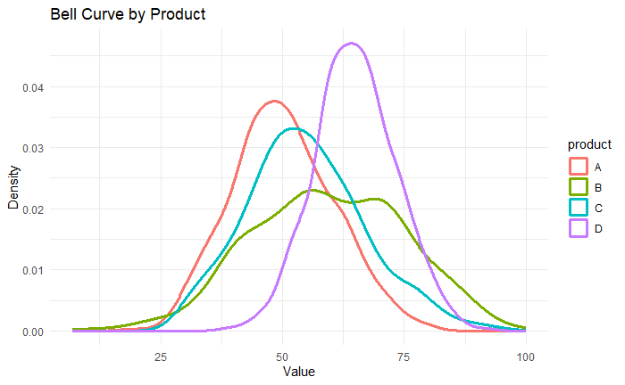

```r
# Read in the data set being analyzed
Sales <- read.csv("C:/Users/Ashem/OneDrive/Desktop/Masters Program - DSC/DSC 520 - Statistics for Data Science/sales_data_sample.csv")

# Create the data frame to build from; there are four product types we want to analyze and
# The amount of rows for the data size is 495 so we make that our outermost value
sales_df <- data.frame(
  product = rep(c("A", "B", "C", "D"), each = 495),
  value = c(rnorm(495, 50, 10), rnorm(495, 60, 15),
            rnorm(495, 55, 12), rnorm(495, 65, 8))
)
# Plot
ggplot(sales_df, aes(x = value, color = product)) +
  geom_density(size = 1.2) +
  labs(title = "Bell Curve by Product",
       x = "Value",
       y = "Density") +
  theme_minimal()
```

```r
# Here I'm looking to see which product had the highest total sales
# Unfortunately, sales don't have a negative value to them unless you are discussing profit or loss, therefore for this particular exercise, a bell curve wouldn't be the best option to show
```

###### Bar Chart

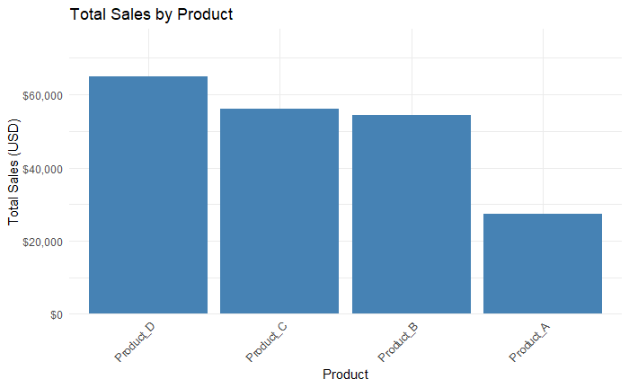

```r
Sales <- read.csv("C:/Users/Ashem/OneDrive/Desktop/Masters Program - DSC/DSC 520 - Statistics for Data Science/sales_data_sample.csv")

# Summarize total sales by product
sales_by_product <- Sales %>%
  group_by(Product) %>%
  summarise(TotalSales = sum(TotalSales, na.rm = TRUE)) %>%
  arrange(desc(TotalSales))

# Plot
ggplot(sales_by_product, aes(x = reorder(Product, -TotalSales), y = TotalSales)) +
  geom_bar(stat = "identity", fill = "steelblue") +
  scale_y_continuous(
  labels = scales::label_dollar(),
  expand = expansion(mult = c(0, 0.2))  # adds 20% vertical padding
) +
  labs(title = "Total Sales by Product",
       x = "Product", y = "Total Sales (USD)") +
  theme_minimal() +
  theme(axis.text.x = element_text(angle = 45, hjust = 1))
```

```r
# The bar Chart gives a better idea visually of which product is conducting better sales over all in terms of revenue.
```

###### Histogram

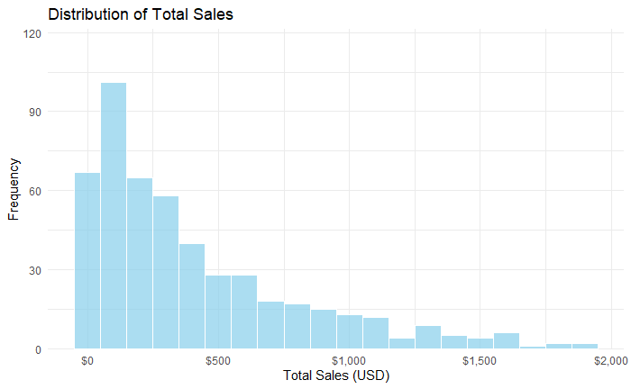

```r
# Load data
Sales <- read.csv("C:/Users/Ashem/OneDrive/Desktop/Masters Program - DSC/DSC 520 - Statistics for Data Science/sales_data_sample.csv")

# Plot histogram
ggplot(Sales, aes(x = TotalSales)) +
  geom_histogram(binwidth = 100, fill = "skyblue", color = "white", alpha = 0.7) +
  scale_y_continuous(expand = expansion(mult = c(0, 0.2))) +  # adds 20% padding above bars
  scale_x_continuous(labels = scales::label_dollar()) +
  labs(title = "Distribution of Total Sales",
       x = "Total Sales (USD)", y = "Frequency") +
  theme_minimal()
```

```r
# Histogram gives a good way to layer our central tendencies and see quick values/patterns. I'll utilize this going forward into that section.
```